# Introduction to Matplotlib

- 2 ways of creating plots (pyplot & OO) - use the OO method
- Plotting data (NumPy arrays), line, scatter, bar, hist, subplots
- Customizing your plots, `limits`, `colors`, `styles`, `legends`
- Saving figures

## 2 ways of creating plots

- `pyplot()`
- `OO` - https://matplotlib.org/api/_as_gen/matplotlib.pyplot.subplots.html
- Matplotlib recommends the OO API
  - https://matplotlib.org/tutorials/introductory/pyplot.html#sphx-glr-tutorials-introductory-pyplot-py
  - https://matplotlib.org/3.1.1/tutorials/introductory/lifecycle.html

Start by importing `Matplotlib` and setting up the `%matplotlib inline` magic command.

```python
# Import matplotlib and setup the figures to display within the notebook
%matplotlib inline
import matplotlib.pyplot as plt
```

```python
# Create a simple plot, without the semi-colon
plt.plot()
```

```
[]
```

```python
# With the semi-colon
plt.plot();
```

```python
# You could use plt.show() if you want
plt.plot()
plt.show()
```

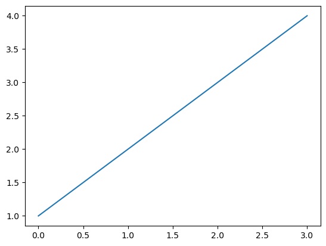

```python
# Let's add some data
plt.plot([1, 2, 3, 4])
```

```python
# Create some data
x = [1, 2, 3, 4]
y = [11, 22, 33, 44]
```

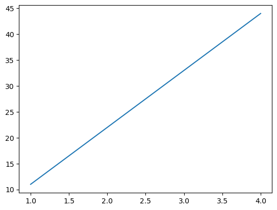

```python
# With a semi-colon and now a y value
plt.plot(x, y);
```

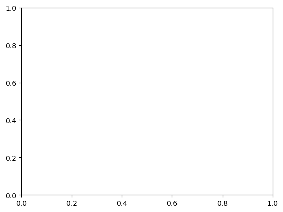

```python
# Creating a plot with the OO verison, confusing way first
fig = plt.figure()
ax = fig.add_subplot()
plt.show()
```

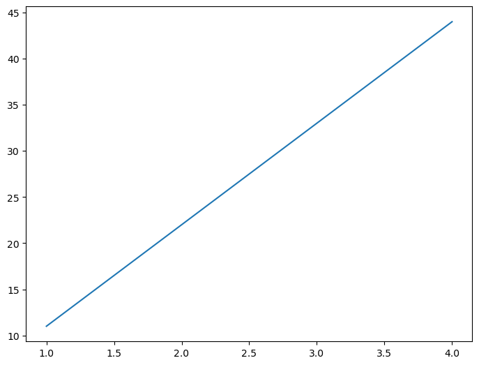

```python
# Confusing #2
fig = plt.figure()
ax = fig.add_axes([1, 1, 1, 1])
ax.plot(x, y)
plt.show()
```

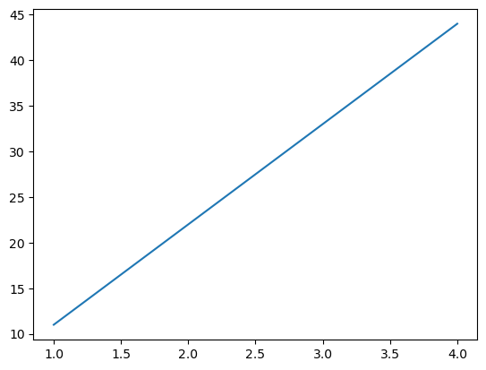

```python
# Easier and more robust going forward (what we're going to use)
fig, ax = plt.subplots()
ax.plot(x, y);
```

## Making the most common type of plots using NumPy arrays

Most of figuring out what kind of plot to use is getting a feel for the data, then see what suits it best.

Matplotlib visualizations are built off NumPy arrays. So in this section we'll build some of the most common types of plots using NumPy arrays.

- `line`
- `scatter`
- `bar`
- `hist`
- `subplots()`

To make sure we have access to NumPy, we'll import it as `np`.

```python
import numpy as np
```

### Line

Line is the default type of visualization in Matplotlib. Usually, unless specified otherwise, your plots will start out as lines.

```python
# Create an array
x = np.linspace(0, 10, 100)
x[:10]
```

```
array([0.        , 0.1010101 , 0.2020202 , 0.3030303 , 0.4040404 ,
       0.50505051, 0.60606061, 0.70707071, 0.80808081, 0.90909091])
```

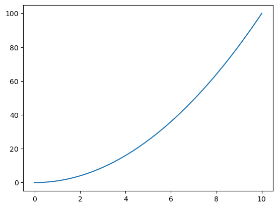

```python
# The default plot is line
fig, ax = plt.subplots()
ax.plot(x, x**2);
```

### Scatter

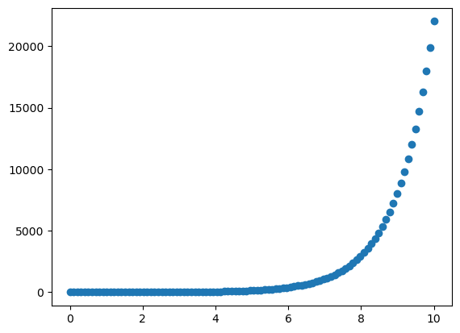

```python
# Need to recreate our figure and axis instances when we want a new figure
fig, ax = plt.subplots()
ax.scatter(x, np.exp(x));
```

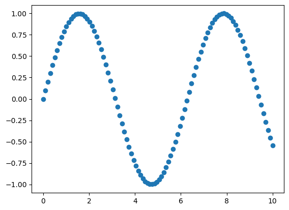

```python
fig, ax = plt.subplots()
ax.scatter(x, np.sin(x));
```

### Bar

- Vertical
- Horizontal

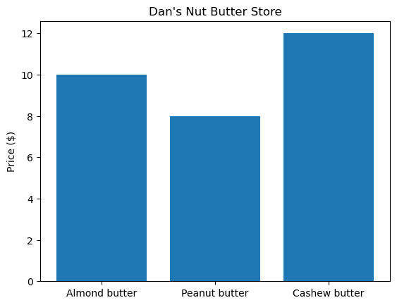

```python
# You can make plots from a dictionary
nut_butter_prices = {"Almond butter": 10,
                     "Peanut butter": 8,
                     "Cashew butter": 12}
fig, ax = plt.subplots()
ax.bar(nut_butter_prices.keys(), nut_butter_prices.values())
ax.set(title="Dan's Nut Butter Store", ylabel="Price ($)");
```

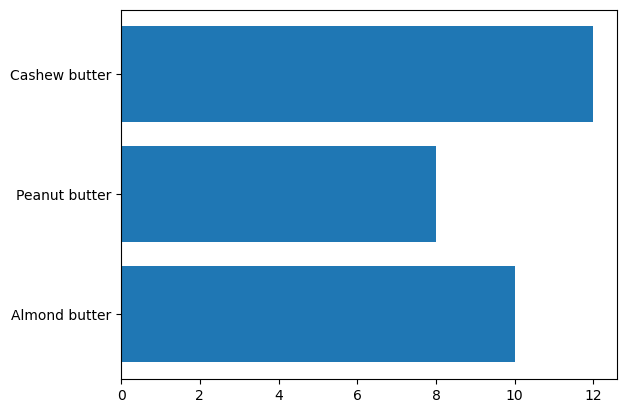

```python
fig, ax = plt.subplots()
ax.barh(list(nut_butter_prices.keys()), list(nut_butter_prices.values()));
```

### Histogram (hist)

- Could show image of normal distribution here

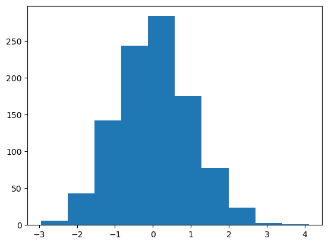

```python
# Make some data from a normal distribution
x = np.random.randn(1000) # pulls data from a normal distribution

fig, ax = plt.subplots()
ax.hist(x);
```

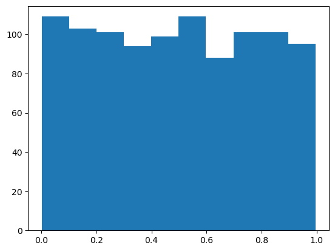

```python
x = np.random.random(1000) # random data from random distribution

fig, ax = plt.subplots()
ax.hist(x);
```

### Subplots

- Multiple plots on one figure https://matplotlib.org/3.1.1/gallery/recipes/create_subplots.html

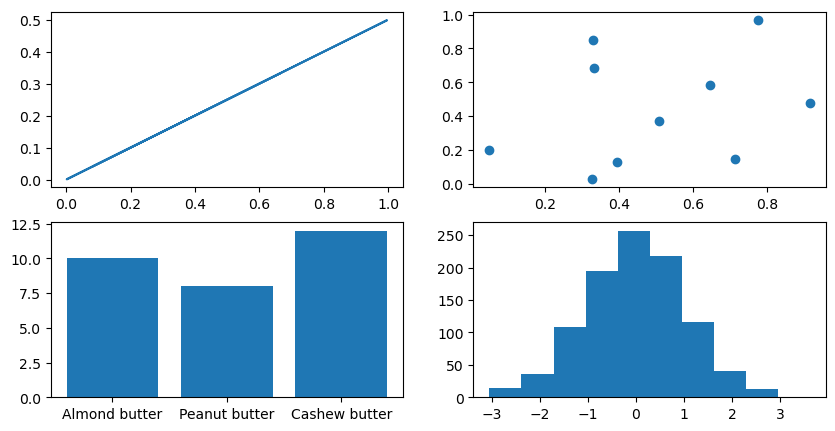

```python
# Option 1: Create multiple subplots
fig, ((ax1, ax2), (ax3, ax4)) = plt.subplots(nrows=2,
                                             ncols=2,
                                             figsize=(10, 5))

# Plot data to each axis
ax1.plot(x, x/2);
ax2.scatter(np.random.random(10), np.random.random(10));
ax3.bar(nut_butter_prices.keys(), nut_butter_prices.values());
ax4.hist(np.random.randn(1000));
```

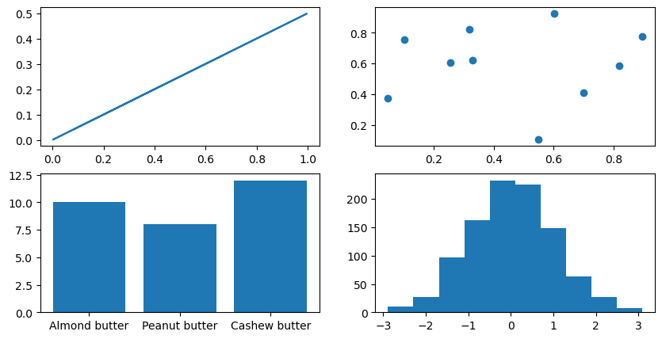

```python
# Option 2: Create multiple subplots
fig, ax = plt.subplots(nrows=2, ncols=2, figsize=(10, 5))

# Index to plot data
ax[0, 0].plot(x, x/2);
ax[0, 1].scatter(np.random.random(10), np.random.random(10));
ax[1, 0].bar(nut_butter_prices.keys(), nut_butter_prices.values());
ax[1, 1].hist(np.random.randn(1000));
```

## Customizing your plots

- `limits (xlim, ylim)`, `colors`, `styles`, `legends`

### Style

```python
plt.style.available
```

```
['Solarize_Light2',
 '_classic_test_patch',
 '_mpl-gallery',
 '_mpl-gallery-nogrid',
 'bmh',
 'classic',
 'dark_background',
 'fast',
 'fivethirtyeight',
 'ggplot',
 'grayscale',
 'seaborn-v0_8',
 'seaborn-v0_8-bright',
 'seaborn-v0_8-colorblind',
 'seaborn-v0_8-dark',
 'seaborn-v0_8-dark-palette',
 'seaborn-v0_8-darkgrid',
 'seaborn-v0_8-deep',
 'seaborn-v0_8-muted',
 'seaborn-v0_8-notebook',
 'seaborn-v0_8-paper',
 'seaborn-v0_8-pastel',
 'seaborn-v0_8-poster',
 'seaborn-v0_8-talk',
 'seaborn-v0_8-ticks',
 'seaborn-v0_8-white',
 'seaborn-v0_8-whitegrid',
 'tableau-colorblind10']
```

```python
# Change the style...
plt.style.use('seaborn-whitegrid')
```

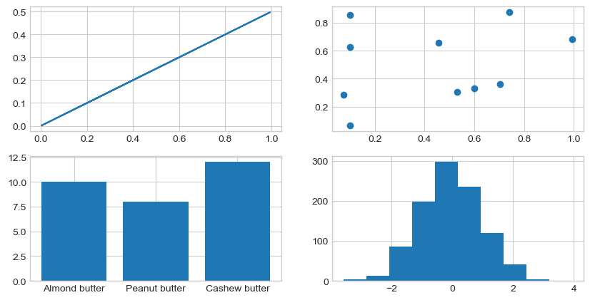

```python
fig, ax = plt.subplots(nrows=2, ncols=2, figsize=(10, 5))

# Index to plot data
ax[0, 0].plot(x, x/2);
ax[0, 1].scatter(np.random.random(10), np.random.random(10));
ax[1, 0].bar(nut_butter_prices.keys(), nut_butter_prices.values());
ax[1, 1].hist(np.random.randn(1000));
```

```python
plt.style.use('seaborn')
```

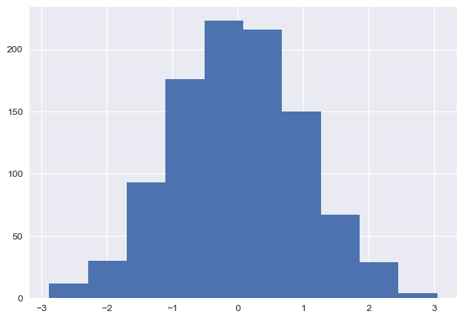

```python
x = np.random.randn(1000) # pulls data from a normal distribution

fig, ax = plt.subplots()
ax.hist(x);
```

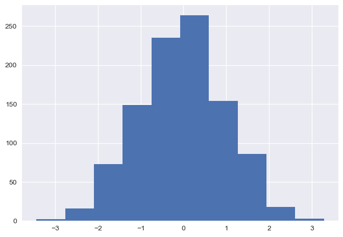

```python
x = np.random.randn(1000) # pulls data from a normal distribution

fig, ax = plt.subplots()
ax.hist(x);
```

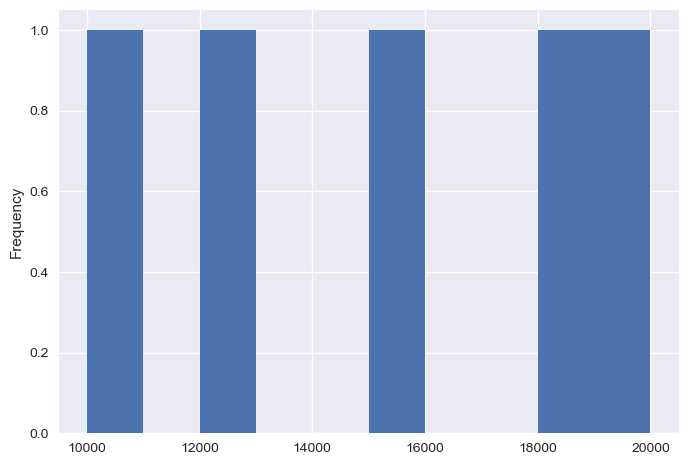

```python
car_sales["Price"].plot.hist()
```

### Changing the title, legend, axes

```python
x = np.random.randn(10, 4)
x
```

```
array([[-0.88768796, -0.34559871,  0.75542273, -0.32418346],
       [-1.10442675,  0.24939911, -0.50381909,  0.02830034],
       [-0.74678561,  0.70051874,  0.14964898, -1.39003562],
       [-1.02479278,  1.38562859,  2.13506049, -1.57603232],
       [-0.96092745,  0.77367782, -0.37611406,  1.00352884],
       [ 0.34939285,  0.2541535 , -0.5396022 ,  1.2957491 ],
       [ 0.28416978, -1.68976517, -0.23793482, -0.38236656],
       [-0.05467131,  0.0704518 , -0.23372401, -1.08323104],
       [ 1.1283887 , -0.27911249,  0.09782548, -1.66046289],
       [ 0.28668015,  0.37073618,  1.56204134, -0.50265995]])
```

```python
df = pd.DataFrame(x, columns=['a', 'b', 'c', 'd'])
df
```

|  | a | b | c | d |
| --- | --- | --- | --- | --- |
| 0 | -0.887688 | -0.345599 | 0.755423 | -0.324183 |
| 1 | -1.104427 | 0.249399 | -0.503819 | 0.028300 |
| 2 | -0.746786 | 0.700519 | 0.149649 | -1.390036 |
| 3 | -1.024793 | 1.385629 | 2.135060 | -1.576032 |
| 4 | -0.960927 | 0.773678 | -0.376114 | 1.003529 |
| 5 | 0.349393 | 0.254153 | -0.539602 | 1.295749 |
| 6 | 0.284170 | -1.689765 | -0.237935 | -0.382367 |
| 7 | -0.054671 | 0.070452 | -0.233724 | -1.083231 |
| 8 | 1.128389 | -0.279112 | 0.097825 | -1.660463 |
| 9 | 0.286680 | 0.370736 | 1.562041 | -0.502660 |

```
matplotlib.axes._axes.Axes
```

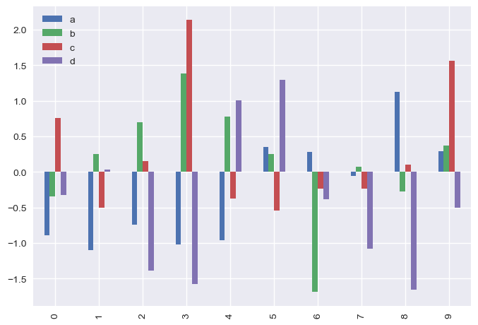

```python
ax = df.plot(kind='bar')
type(ax)
```

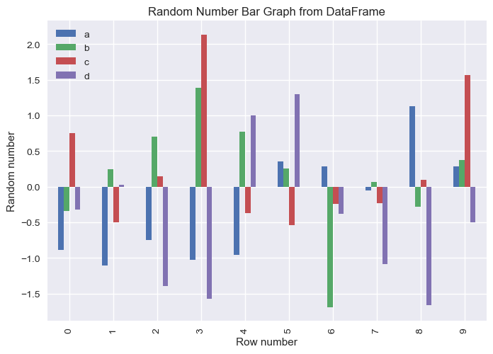

```python
ax = df.plot(kind='bar')
ax.set(title="Random Number Bar Graph from DataFrame",
       xlabel="Row number",
       ylabel="Random number")
ax.legend().set_visible(True)
```

## Saving plots

If you're doing something like this often, to save writing excess code, you might put it into a function.

```python
# Check the supported filetypes
fig.canvas.get_supported_filetypes()
```

```
{'eps': 'Encapsulated Postscript',
 'jpg': 'Joint Photographic Experts Group',
 'jpeg': 'Joint Photographic Experts Group',
 'pdf': 'Portable Document Format',
 'pgf': 'PGF code for LaTeX',
 'png': 'Portable Network Graphics',
 'ps': 'Postscript',
 'raw': 'Raw RGBA bitmap',
 'rgba': 'Raw RGBA bitmap',
 'svg': 'Scalable Vector Graphics',
 'svgz': 'Scalable Vector Graphics',
 'tif': 'Tagged Image File Format',
 'tiff': 'Tagged Image File Format',
 'webp': 'WebP Image Format'}
```

```python
# Save the file
fig.savefig("figname.png")
```

## Tasks

Read any data you have (CSV, Seaborn dataset) etc.

```python
# Make histograms, scatter diagrams, etc figures based on data
# try to create figures containing several subfigures (subplots)
# Save each figure
```

```python
import pandas as pd

df = pd.read_csv("Other.csv")
df
```

|  | Activity Type | Date | Favorite | Title | Distance | Calories | Time | Avg HR | Max HR | Aerobic TE | ... | Min Temp | Surface Interval | Decompression | Best Lap Time | Number of Laps | Max Temp | Moving Time | Elapsed Time | Min Elevation | Max Elevation |
| --- | --- | --- | --- | --- | --- | --- | --- | --- | --- | --- | --- | --- | --- | --- | --- | --- | --- | --- | --- | --- | --- |
| 0 | Other | 2023-10-09 15:46:32 | False | Salibandy | 0,00 | 337 | 01:18:04 | 100 | 147 | 1,7 | ... | 25,0 | 0:00 | No | 01:18:04.31 | 1 | 30,0 | 00:00:00 | 01:18:04 | 40 | 40 |
| 1 | Other | 2023-10-02 15:48:20 | False | Salibandy | 0,00 | 382 | 01:14:14 | 108 | 160 | 2,1 | ... | 26,0 | 0:00 | No | 01:14:13.85 | 1 | 31,0 | 00:00:00 | 01:14:14 | 57 | 62 |
| 2 | Other | 2023-09-25 15:47:52 | False | Salibandy | 0,00 | 493 | 01:14:22 | 118 | 170 | 3,1 | ... | 27,0 | 0:00 | No | 01:14:21.83 | 1 | 32,0 | 00:00:00 | 01:14:22 | -14 | -0 |
| 3 | Other | 2023-09-18 15:52:30 | False | Salibandy | 0,00 | 306 | 01:10:39 | 101 | 139 | 1,4 | ... | 26,0 | 0:00 | No | 01:10:38.71 | 1 | 30,0 | 00:00:00 | 01:10:39 | 58 | 64 |
| 4 | Other | 2023-09-11 15:46:16 | False | Salibandy | 0,00 | 392 | 01:16:46 | 107 | 155 | 2,1 | ... | 27,0 | 0:00 | No | 01:16:45.54 | 1 | 32,0 | 00:00:00 | 01:16:46 | 46 | 58 |
| ... | ... | ... | ... | ... | ... | ... | ... | ... | ... | ... | ... | ... | ... | ... | ... | ... | ... | ... | ... | ... | ... |
| 184 | Other | 2017-12-18 17:16:59 | False | Salibandy | 1,61 | 319 | 01:15:00 | 95 | 148 | 1,8 | ... | 25,0 | 0:00 | No | 00:00.00 | 3 | 30,0 | 00:20:10 | 01:15:33 | 168 | 176 |
| 185 | Other | 2015-05-17 05:33:32 | False | aamu pulssi | 0,00 | 133 | 02:29:15 | 48 | 80 | -- | ... | 0,0 | 0:00 | No | 00:00.00 | -- | 0,0 | 00:00:00 | 00:00:00 | -- | -- |
| 186 | Other | 2014-10-08 20:52:05 | False | Salibandy? | 0,00 | 523 | 01:13:49 | 115 | 161 | -- | ... | 0,0 | 0:00 | No | 00:00.00 | -- | 0,0 | 00:00:00 | 00:00:00 | -- | -- |
| 187 | Other | 2014-05-16 19:38:07 | False | salibandy | 0,00 | 730 | 01:26:08 | 124 | 152 | -- | ... | 0,0 | 0:00 | No | 00:00.00 | -- | 0,0 | 00:00:00 | 00:00:00 | -- | -- |
| 188 | Other | 2014-01-24 19:35:01 | False | Sähly | 0,00 | 775 | 01:27:42 | 134 | 188 | -- | ... | 0,0 | 0:00 | No | 00:00.00 | -- | 0,0 | 00:00:00 | 00:00:00 | -- | -- |

189 rows × 39 columns

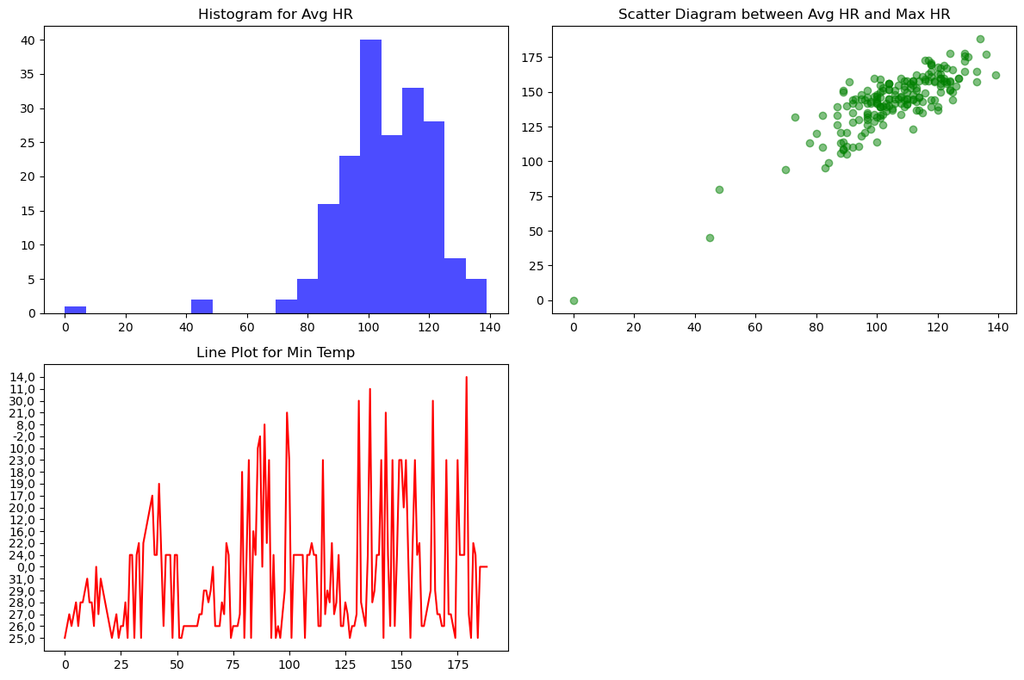

```python
import pandas as pd
import matplotlib.pyplot as plt

# Load data from a CSV file
df = pd.read_csv("Other.csv")

# Create histograms, scatter diagrams, etc.
plt.figure(figsize=(12, 8))

# Subplot 1: Histogram
plt.subplot(2, 2, 1)
plt.hist(df['Avg HR'], bins=20, color='blue', alpha=0.7)
plt.title('Histogram for Avg HR')

# Subplot 2: Scatter Diagram
plt.subplot(2, 2, 2)
plt.scatter(df['Avg HR'], df['Max HR'], color='green', alpha=0.5)
plt.title('Scatter Diagram between Avg HR and Max HR')

# Subplot 3: Another type of plot (e.g., line plot)
plt.subplot(2, 2, 3)
plt.plot(df['Min Temp'], color='red')
plt.title('Line Plot for Min Temp')

# Adjust layout to prevent overlap
plt.tight_layout()

# Save each figure
plt.savefig('figure1.png')

# Show the figure
plt.show()
```